# Project_6

Sarah Eiben, Michelle Baumgartner, Deni Hodzic

2022-06-16

```r
load("objects_p2.RData")
load("objects_p3.RData")
```

```r
suppressPackageStartupMessages({
  library(GenomicRanges)
  library(epiwraps)
  library(ggplot2)
  library(rGREAT)
  library(AnnotationHub)
  library(Rsubread)
  library(rtracklayer)
  library(Biostrings)
  library(Rfastp)
  library(ensembldb)
  library(bsseq)
  library(BiocParallel)
  library(edgeR)
  library(DMRcate)
})
```

# Doing the previous things for the whole genome

We are trying to do this for the whole genome:

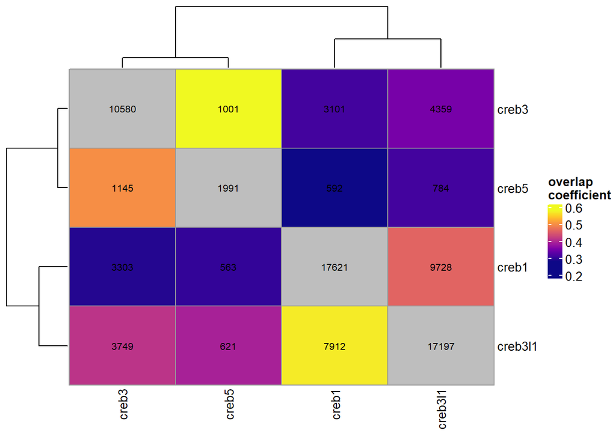

```r
listofRegions_whole <- list(creb1=peaks_creb1, creb3=peaks_creb3, creb3l1=peaks_creb3l1, creb5=peaks_creb5)
regionOverlaps(listofRegions_whole)
```

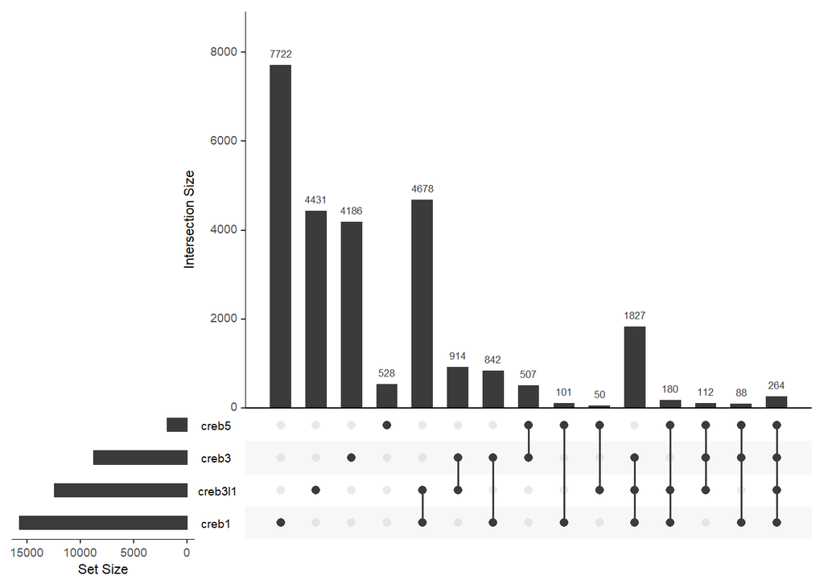

```r
regionUpset(listofRegions_whole)
```

Figure 6.1a: A regionOverlaps plot of the CREB family members for the whole genome Figure 6.1b: A regionUpset plot of the CREB family members for the whole genome

## Comparison to chromosome 1

In order to be able to compare it better to what only chromosome 1 looked like, we are adding the chromosome 1 UpsetPlot here as well.

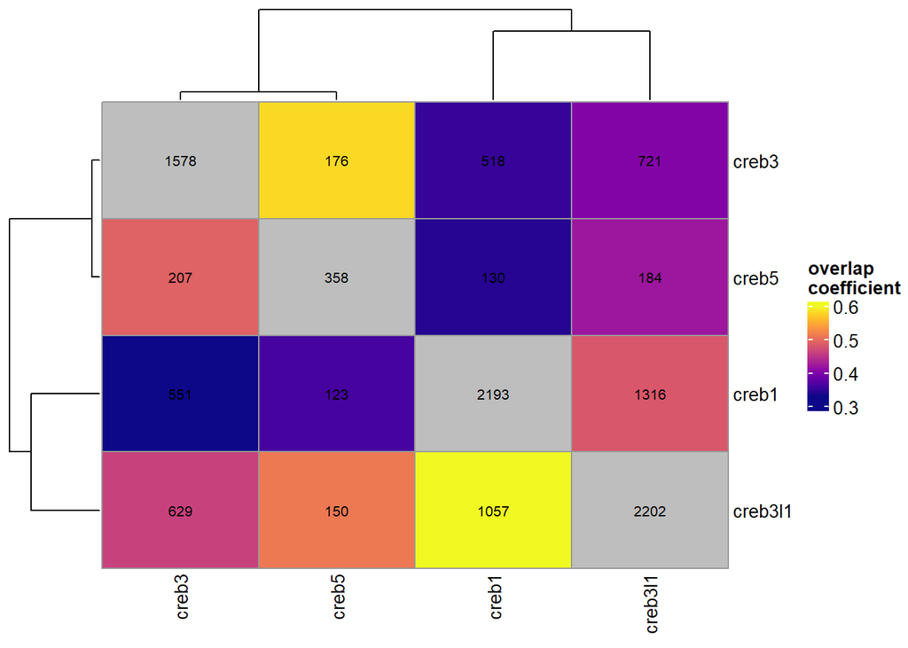

```r
listofRegions <- list(creb1=peaks_creb1_chr1, creb3=peaks_creb3_chr1, creb3l1=peaks_creb3l1_chr1, creb5=peaks_creb5_chr1)
regionOverlaps(listofRegions)
```

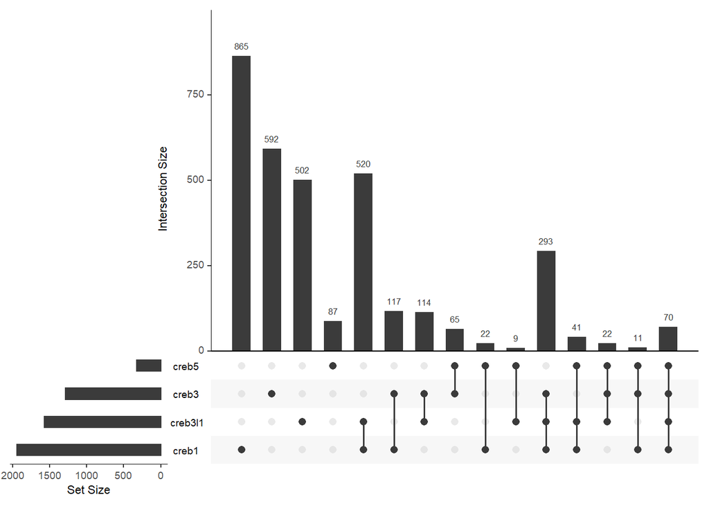

```r
regionUpset(listofRegions)
```

Figure 6.2: The plots from chromosome 1 again for comparison

Of course the numbers differ when comparing chromosome 1 to the whole genome but the overall dimensions seem to be very similar.

## Restricting to CREB1 sites

Here we tried out how the upsetplot changes when we restrict it to CREB1.

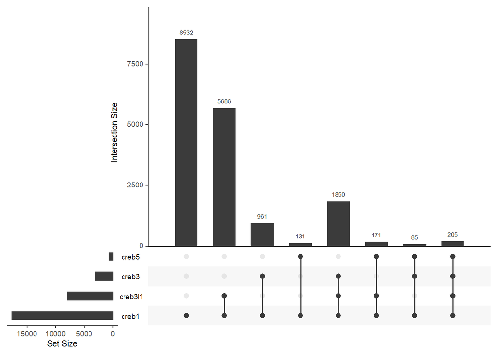

```r
regionUpset(listofRegions_whole, reference = peaks_creb1)
```

Figure 6.3: A regionUpset plot of the CREB family members of the whole genome restricted to CREB1 sites.

## Restricting to CREB3 sites

Here we tried out how the upsetplot changes when we restrict it to CREB3.

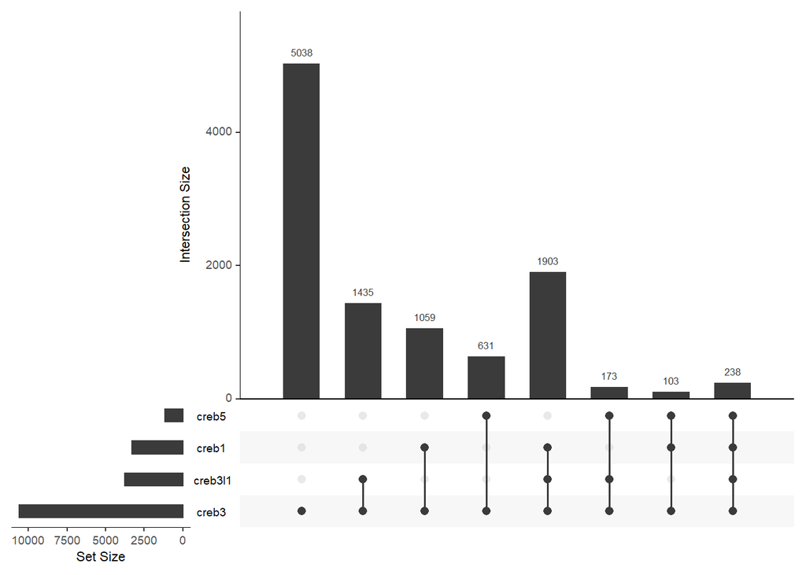

```r
regionUpset(listofRegions_whole, reference = peaks_creb3)
```

Figure 6.4: A regionUpset plot of the CREB family members of the whole genome restricted to CREB3 sites.

## Restricting to CREB3L1 sites

Here we tried out how the upsetplot changes when we restrict it to CREB3L1.

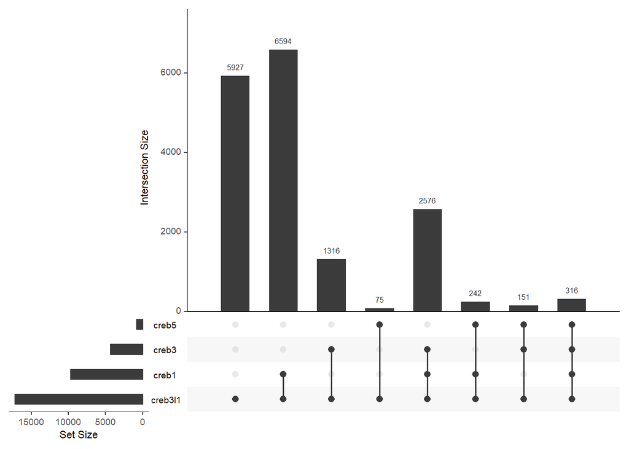

```r
regionUpset(listofRegions_whole, reference = peaks_creb3l1)
```

Figure 6.5: A regionUpset plot of the CREB family members of the whole genome restricted to CREB3L1 sites.

## Restricting to CREB5 sites

Here we tried out how the upsetplot changes when we restrict it to CREB5.

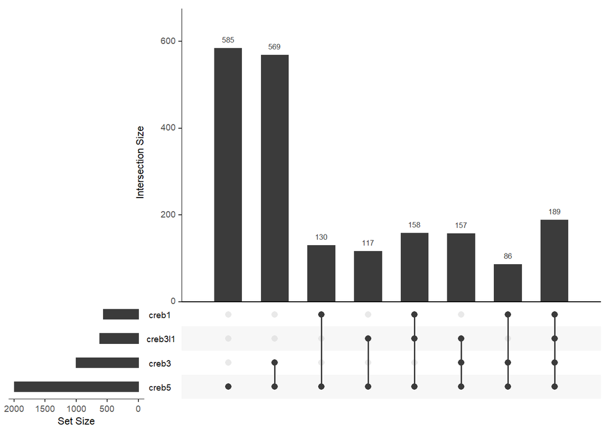

```r
regionUpset(listofRegions_whole, reference = peaks_creb5)
```

Figure 6.6: A regionUpset plot of the CREB family members of the whole genome restricted to CREB5 sites.

# How do these plots make sense?

Looking at the plots above we can find the most interactions between CREB1 and CREB3l1, followed by CREB3 and CREB3l1, the least interactions are found with CREB5, which mainly interacts with CREB3.

# Clustering of the signals and enrichment analysis

## Plotting the signals

```r
# create a list with all the peaks on the whole genome
peak_list_whole <- GRangesList("Peaks CREB1"=peaks_creb1, "Peaks CREB3"=peaks_creb3, "Peaks CREB3L1"=peaks_creb3l1, "Peaks CREB5"=peaks_creb5, compress=TRUE)
# merge the peaks together to create one list of non-overlapping regions
merged_peaks_whole <- reduce(unlist(peak_list_whole))
# make a list of the signal p-values
pv_list_whole <- list(CREB1="signal_pv_creb/signal_pv_creb1.bw", CREB3="signal_pv_creb/signal_pv_creb3.bw", CREB3L1="signal_pv_creb/signal_pv_creb3l1.bw", CREB5="signal_pv_creb/Signal_pv_creb5.bw")
# we obtain the matrix of the signal around the regions:
m_creb1_whole <- signal2Matrix(pv_list_whole, merged_peaks_whole)
```

```
## Reading signal_pv_creb/signal_pv_creb1.bw
```

```
## Reading signal_pv_creb/signal_pv_creb3.bw
```

```
## Reading signal_pv_creb/signal_pv_creb3l1.bw
```

```
## Reading signal_pv_creb/Signal_pv_creb5.bw
```

```
## `use_raster` is automatically set to TRUE for a matrix with more than
## 2000 rows. You can control `use_raster` argument by explicitly setting
## TRUE/FALSE to it.
##
## Set `ht_opt$message = FALSE` to turn off this message.
```

[output not shown]

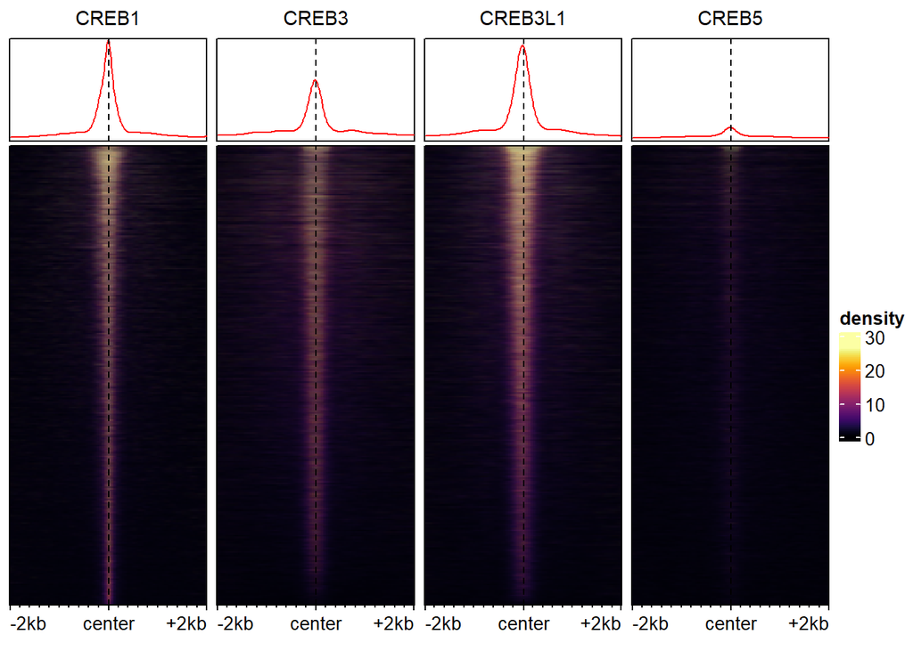

```r
# maybe set an extend and a width?
plotEnrichedHeatmaps(m_creb1_whole)
```

Figure 6.7: A heatmap of the signals from the whole genome for the CREB family members

Here comes up the question how you want to analyze the whole genome. Going off of the whole genome for the heatmaps altogether makes not so much sense, since then you cannot divide it up into logical groups or assign it back to the original genome. So it would make more sense to cluster gene after gene and then compare them to eachother.

This was initially our goal but as we had neither enough processing power or time to let this all run for the whole genome so we selected one more chromosome based on this paper: https://www.ncbi.nlm.nih.gov/pmc/articles/PMC387762/ The chosen chromosome would be chromosome 22, since according to this paper CREB1 binds to many sites on this chromosome. Let’s find out how it is for the other CREB family members.

## Restricting all of the CREB family memeber peaks to chromosome 22

```r
# CREB1
peaks_creb1_chr22 <- peaks_creb1[seqnames(peaks_creb1)=="chr22"]
# CREB3
peaks_creb3_chr22 <- peaks_creb3[seqnames(peaks_creb3)=="chr22"]
# CREB3L1
peaks_creb3l1_chr22 <- peaks_creb3l1[seqnames(peaks_creb3l1)=="chr22"]
# CREB5
peaks_creb5_chr22 <- peaks_creb5[seqnames(peaks_creb5)=="chr22"]
```

## Creating a regionOverlap and a regionUpset for all CREB family members for chromosome 22

First we create an Overlap of the peaks of chromosome 22 of all CREB family members and an Upsetplot of the same regions.

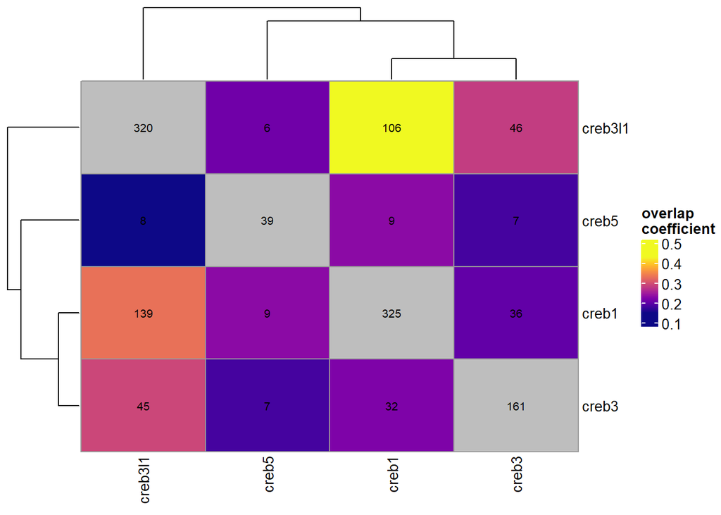

```r
listofRegions_22 <- list(creb1=peaks_creb1_chr22, creb3=peaks_creb3_chr22, creb3l1=peaks_creb3l1_chr22, creb5=peaks_creb5_chr22)
regionOverlaps(listofRegions_22)
```

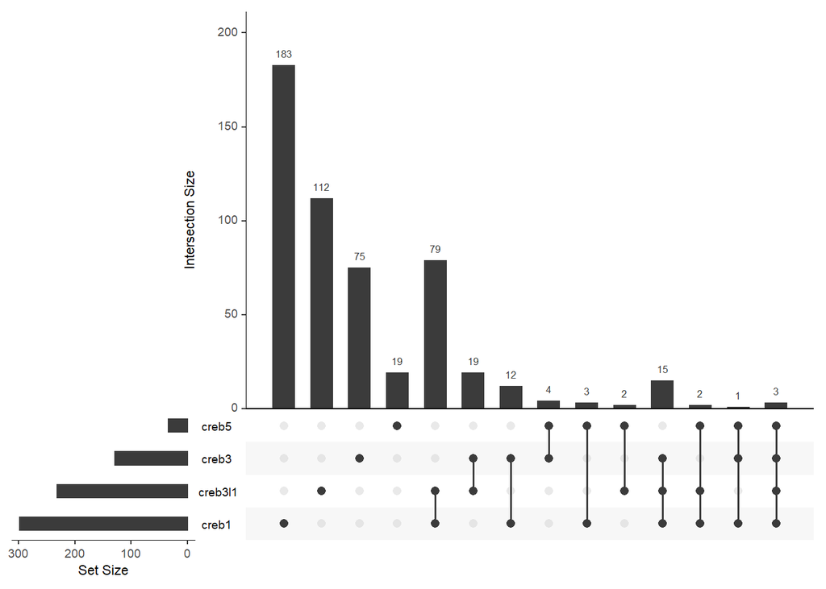

```r
regionUpset(listofRegions_22)
```

Figure 6.8a: A regionOverlaps plot for chromosome 22 Figure 6.8b: A regionUpset plot for chromosome 22

# Restricting to CREB1

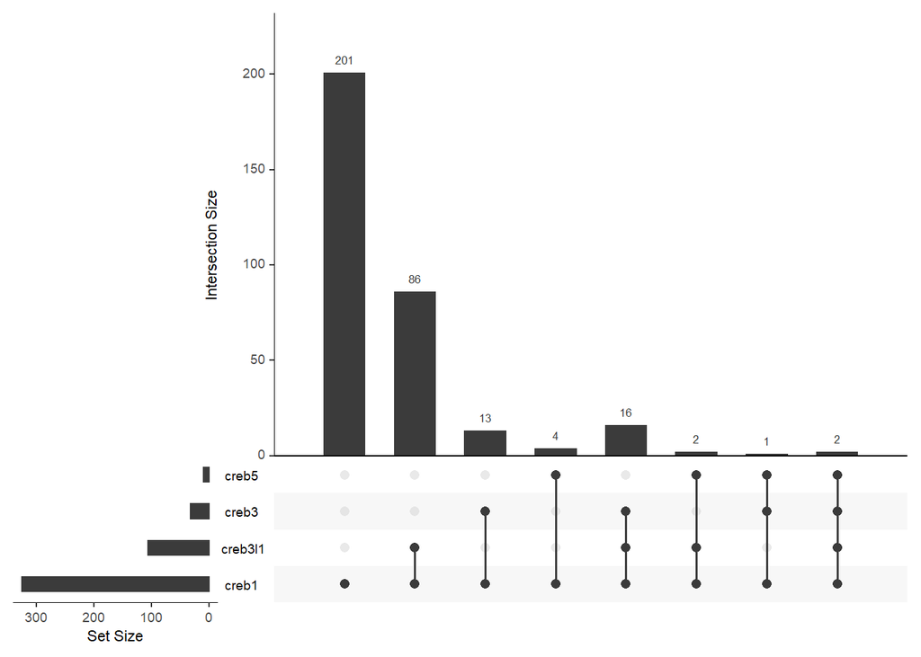

```r
regionUpset(listofRegions_22, reference = peaks_creb1_chr22)
```

Figure 6.9: A regionUpset plot for chromosome 22 restricted to CREB1

## Restricting to CREB3 sites

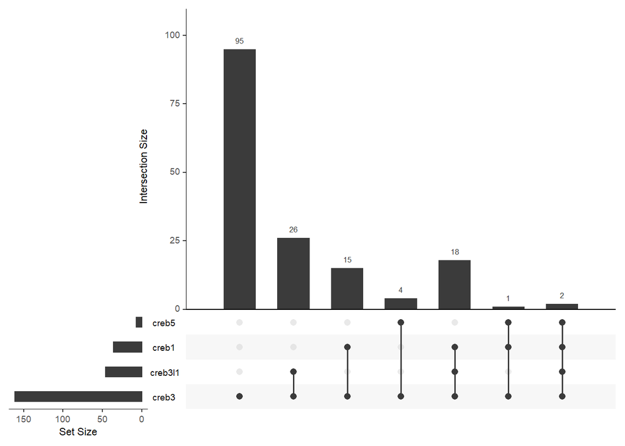

```r
regionUpset(listofRegions_22, reference = peaks_creb3_chr22)
```

Figure 6.10: A regionUpset plot for chromosome 22 restricted to CREB3

## Restricting to CREB3L1 sites

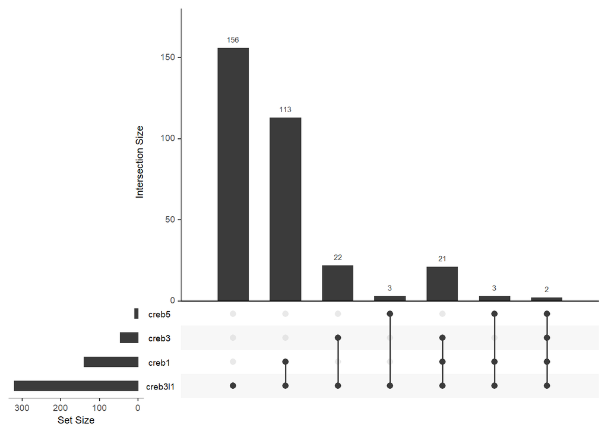

```r
regionUpset(listofRegions_22, reference = peaks_creb3l1_chr22)
```

Figure 6.11: A regionUpset plot for chromosome 22 restricted to CREB3L1

## Restricting to CREB5 sites

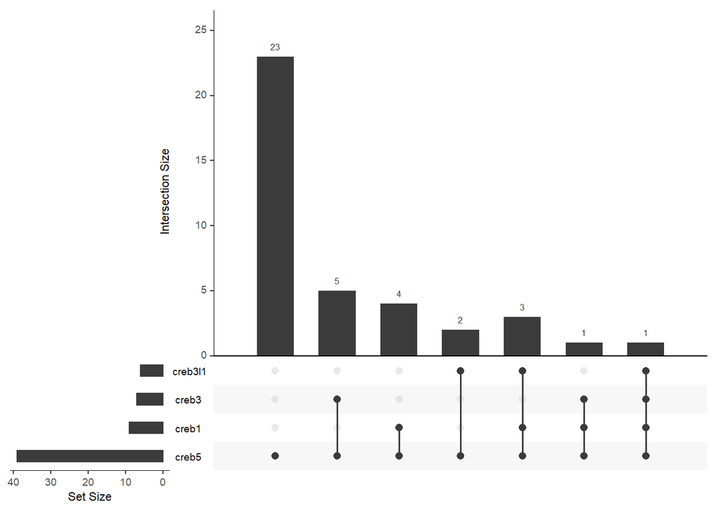

```r
regionUpset(listofRegions_22, reference = peaks_creb5_chr22)
```

Figure 6.12: A regionUpset plot for chromosome 22 restricted to CREB5

## Explain how these plots make sense? How do they compare to chr1?

In comparison to chromosome 1 there are a lot fewer intersections of the CREB family members on chromosome 22. CREB3 seems to be less expressed on chromosome 22 compared to chromosome 1, which also leads to smaller intersection sizes with other family members.

The patterns of the restricted plots are also very similar with the exception of CREB5 which has more intersections with CREB3 and CREB1 than with CREB3L1 but the numbers are very close.

Here we tried to add clustering and enrichment analysis of these signals but R didn’t cooperate. We got an error that some of the files didn’t exist, even though we created the files in the same chunk, just like the other times before. We didn’t find a solution for this problem, so we let it be.

This did not work: # Clustering of the signals and enrichment analysis of chromosome 22

## Plotting the signals

```r
# create a list with all the peaks on chromosome 22
peak_list_22 <- GRangesList("Peaks CREB1"=peaks_creb1_chr22, "Peaks CREB3"=peaks_creb3_chr22, "Peaks CREB3L1"=peaks_creb3l1_chr22, "Peaks CREB5"=peaks_creb5_chr22, compress=TRUE)
# merge the peaks together to create one list of non-overlapping regions
merged_peaks_22 <- reduce(unlist(peak_list_22))
# make a list of the signal p-values
pv_list_22 <- list(CREB1="signal_pv_creb/signal_pv_creb1.bw.bw", CREB3="signal_pv_creb/signal_pv_creb3.bw", CREB3L1="signal_pv_creb/signal_pv_creb3l1.bw", CREB5="signal_pv_creb/Signal_pv_creb5.bw")
# we obtain the matrix of the signal around the regions:
m_creb1_22 <- signal2Matrix(pv_list_22, merged_peaks_22)
plotEnrichedHeatmaps(m_creb1_22)
```

Hence this did not work and the following steps up to #Adding the cofactors and one acetylation tot he analysis DID NOT WORK ## Clustering

```r
cl_22 <- clusterSignalMatrices(m_creb1_22, k=10)
# with 5 clusters 73% of the variance is explained by clusters
# with 4 clusters 64 % of the variance is explained by clusters
# with 6 clusters 77%
# with 7 clusters 80%
# with 8 clusters 82%
# with 9 clusters 84%
# with 10 clusters 85%
# with 11 clusters 86%
# so let's go with 10 clusters and see what we can tell.
table(cl_22)
head(cl_22)
length(cl_22)
# The numbers at [1] tell you where your regions are: first region is in cluster 10 with 303 elements
merged_peaks_22$cluster <- cl_22
```

### Plotting the clusters

```r
set.seed(123)
plotEnrichedHeatmaps(m_creb1_22, row_split=cl_22)
```

#### Adding colors

```r
# create a vector of colors and have as names of the vector the names of our clusters (in this case just numbers).
mycolors <- c("1"="yellow", "2"="orange", "3"="red", "4"="pink", "5"="purple", "6"="blue", "7"="green", "8"="brown", "9"="gray", "10"="black")
plotEnrichedHeatmaps(m_creb1_22, row_split=cl_22, mean_color=mycolors, trim=c(0.95))
```

## Plotting just the averages

```r
d_22 <- meltSignals(m_creb1_22, splitBy=cl)
ggplot(d_22, aes(position, mean, colour=sample)) + geom_line(size=1.2) + facet_wrap(~split)
```

# Enrichment analysis

```r
# we first split the regions by cluster:
split_regions_22 <- split(merged_peaks_22, cl_22)
# Important: when a job is submitted to GREAT a set of regions, a GRanges object, needs to be submitted BUT there also needs to be some sort of background added to the picture. The elements in a list of regions are always compared to other elements. So we are comparing the regions in cluster 6 with respect to all our other regions.
# sending the data to the server
job_22 <- submitGreatJob(split_regions_22[["2"]], merged_peaks_22, species="hg38")
#Human GRCh38/hg38 is the genome we used
job_22
# we fetch the data back
res_22 <- getEnrichmentTables(job_22)
names(res_22)
```

## Plotting the top Biological Processes, molecular functions and cellular components of Cluster 2

```r
# looking at the biological processes
bp_22 <- res_2$`GO Biological Process`
head(bp_22)
# reorder it from most to least statistically significant before being alphabetically ordered.
ggplot(head(bp_22,20), aes(Hyper_Fold_Enrichment, reorder(name, Hyper_Adjp_BH), size=Hyper_Foreground_Region_Hits, color=-log10(Hyper_Adjp_BH))) + geom_point() + scale_color_viridis_c()

# looking at the molecular function
mf_22 <- res_2$`GO Molecular Function`
head(mf_22)
ggplot(head(mf_22,20), aes(Hyper_Fold_Enrichment, reorder(name, Hyper_Adjp_BH), size=Hyper_Foreground_Region_Hits, color=-log10(Hyper_Adjp_BH))) + geom_point() + scale_color_viridis_c()

# looking at cellular components
cc_22 <- res_2$`GO Cellular Component`
ggplot(head(cc_22,20), aes(Hyper_Fold_Enrichment, reorder(name, Hyper_Adjp_BH), size=Hyper_Foreground_Region_Hits, color=-log10(Hyper_Adjp_BH))) + geom_point() + scale_color_viridis_c()
```

# Adding the cofactors and one acetylation to the analysis

```r
# get the regions on the cofactors and the methylation for just chromosome 22
# CREBBP
peaks_crebbp_chr22 <- peaks_crebbp[seqnames(peaks_crebbp)=="chr22"]
# CREB3
peaks_jun_chr22 <- peaks_jun[seqnames(peaks_jun)=="chr22"]
# CREB3L1
peaks_ep300_chr22 <- peaks_ep300[seqnames(peaks_ep300)=="chr22"]
# CREB5
peaks_hdac2_chr22 <- peaks_hdac2[seqnames(peaks_hdac2)=="chr22"]
# H3K27ac
peaks_h3k27ac_chr22 <- peaks_h3k27ac[seqnames(peaks_h3k27ac)=="chr22"]
```

## Creating a regionOverlap and a regionUpset for all CREB family members for chromosome 22 AND the cofactors and acetylation

We make a list of regions that includes the cofactors and the acetylation to it and use this list to do another regionOverlaps and regionUpset plot.

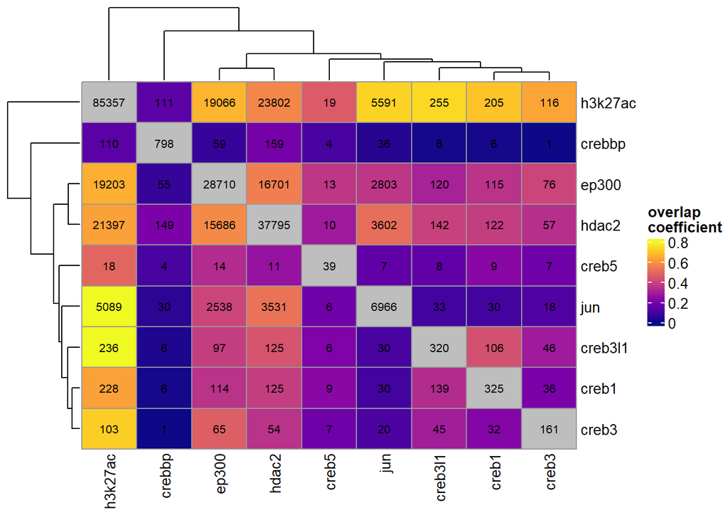

```r
listofRegions_cf_22 <- list(creb1=peaks_creb1_chr22, creb3=peaks_creb3_chr22, creb3l1=peaks_creb3l1_chr22, creb5=peaks_creb5_chr22, crebbp=peaks_crebbp, jun=peaks_jun, ep300=peaks_ep300, hdac2=peaks_hdac2, h3k27ac=peaks_h3k27ac)
regionOverlaps(listofRegions_cf_22)
```

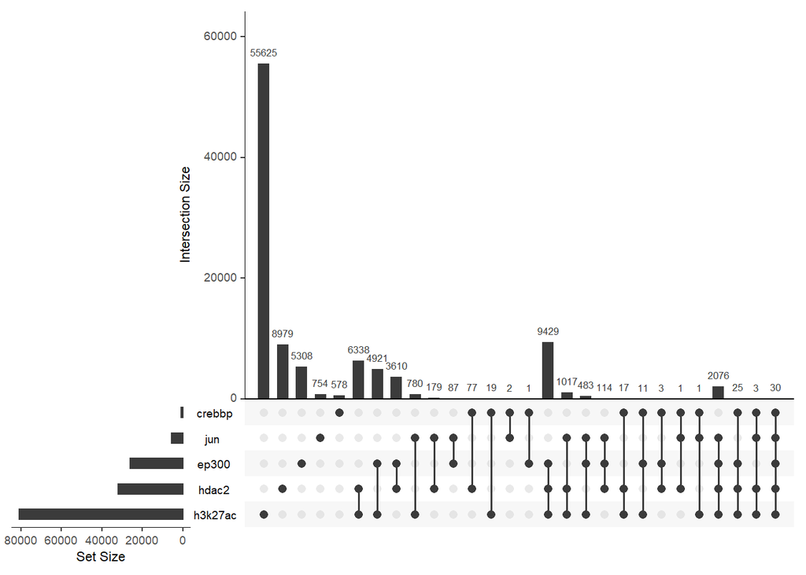

```r
regionUpset(listofRegions_cf_22)
```

What stands out in this RegionOverlaps plot is that the cofactor hdac2 overlaps strongly with the acetylation h3k27ac.

CREB5 seems to have the least overlaps.

The RegionUpset plot shows that the acetylations have by far the biggest intersection size and most intersections are also shown with its involvement. This acetylation seems to be very present.

### Creating different regionOverlap plots and regionUpset plots to see it more clearly

Following we are creating more specific plots by focusing on one cofactor or acetylation. We add our focus into the list of CREB family members and leave the others away. To analyze these we can set the reference to different CREB family members which might give us some different information.

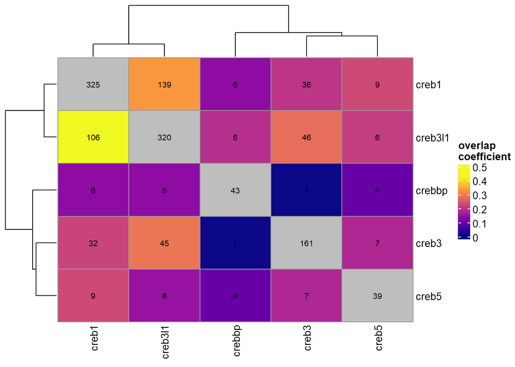

```r
# CREBBP
listofRegions_crebbp_22 <- list(creb1=peaks_creb1_chr22, creb3=peaks_creb3_chr22, creb3l1=peaks_creb3l1_chr22, creb5=peaks_creb5_chr22, crebbp=peaks_crebbp_chr22)
regionOverlaps(listofRegions_crebbp_22)
```

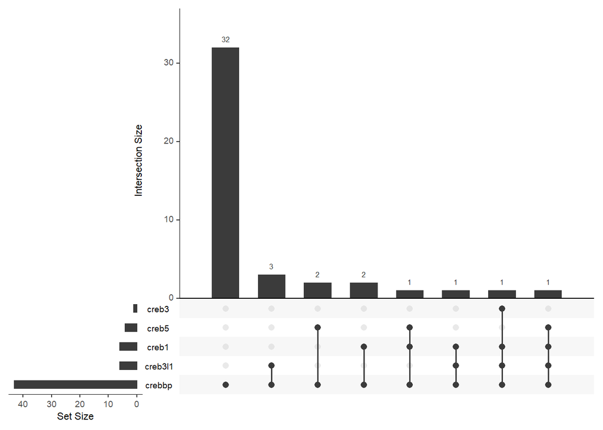

```r
regionUpset(listofRegions_crebbp_22, reference = peaks_crebbp_chr22)
```

Figure 6.14a: A regionOverlaps plot for CREB family members plus CREBBP for chromosome 22 Figure 6.14b: A regionUpset plot for CREB family members plus CREBBP for chromosome 22

CREBBP seems not to have very many overlaps with any of the CREB family members on chromosome 22.

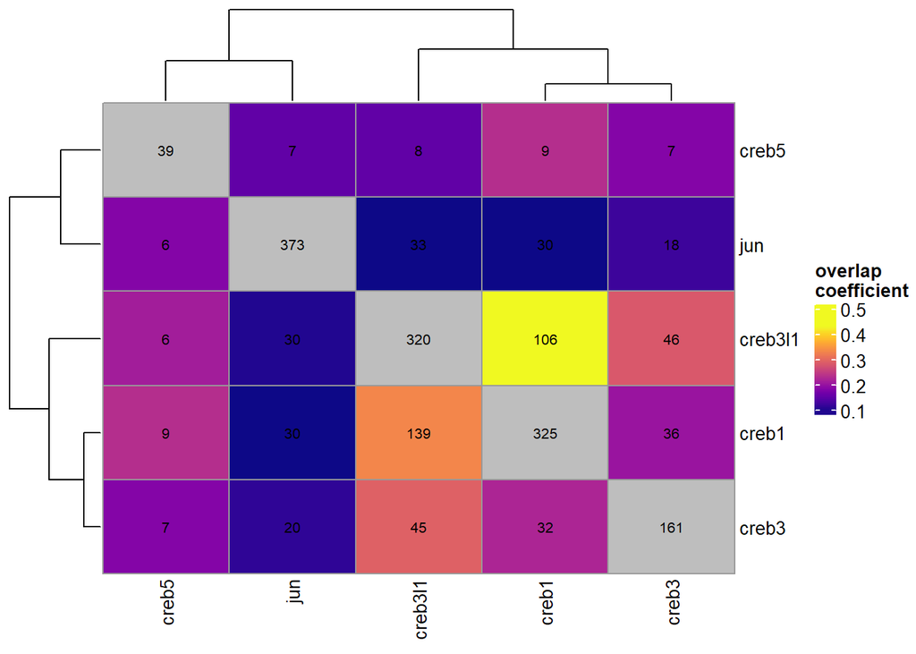

```r
# JUN
listofRegions_jun_22 <- list(creb1=peaks_creb1_chr22, creb3=peaks_creb3_chr22, creb3l1=peaks_creb3l1_chr22, creb5=peaks_creb5_chr22, jun=peaks_jun_chr22)
regionOverlaps(listofRegions_jun_22)
```

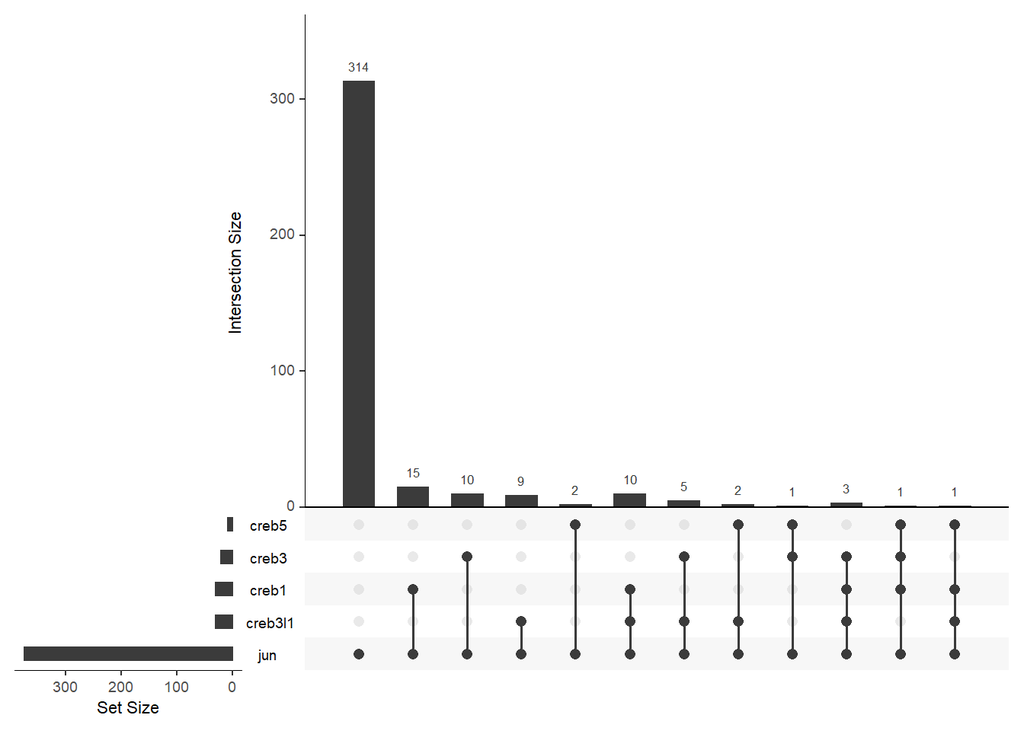

```r
regionUpset(listofRegions_jun_22, reference = peaks_jun_chr22)
```

Figure 6.15a: A regionOverlaps plot for CREB family members plus JUN for chromosome 22 Figure 6.15b: A regionUpset plot for CREB family members plus JUN for chromosome 22

JUN seems not to have very many overlaps with any of the CREB family members on chromosome 22.

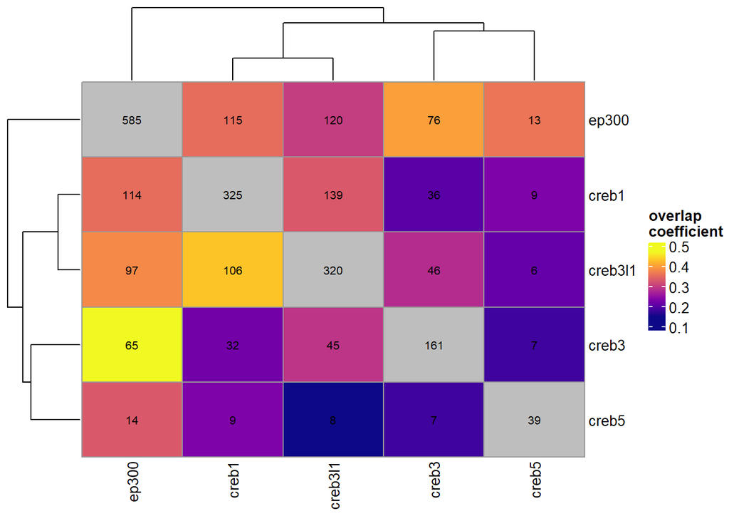

```r
# EP300
listofRegions_ep300_22 <- list(creb1=peaks_creb1_chr22, creb3=peaks_creb3_chr22, creb3l1=peaks_creb3l1_chr22, creb5=peaks_creb5_chr22, ep300=peaks_ep300_chr22)
regionOverlaps(listofRegions_ep300_22)
```

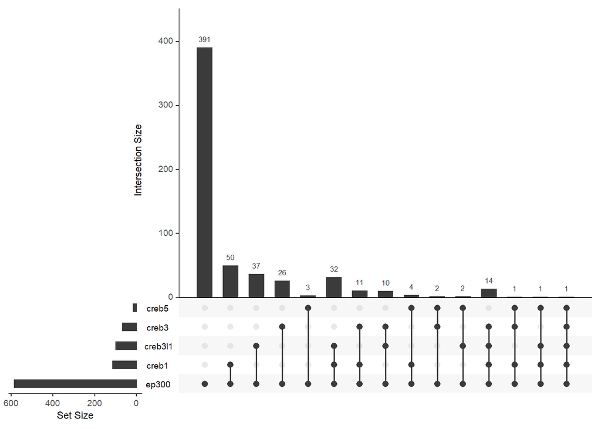

```r
regionUpset(listofRegions_ep300_22, reference = peaks_ep300_chr22)
```

Figure 6.16a: A regionOverlaps plot for CREB family members plus EP300 for chromosome 22 Figure 6.16b: A regionUpset plot for CREB family members plus EP300 for chromosome 22

EP300 also seems to have little intersections with the CREB family members but most with CREB1.

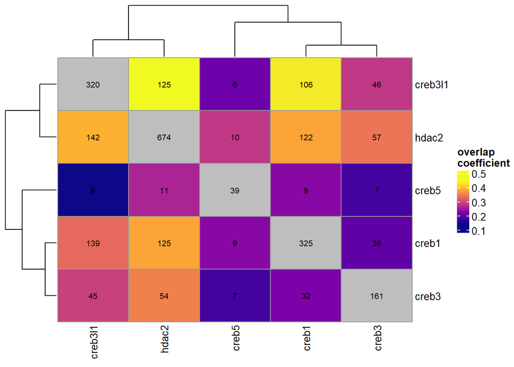

```r
# HDAC2
listofRegions_hdac2_22 <- list(creb1=peaks_creb1_chr22, creb3=peaks_creb3_chr22, creb3l1=peaks_creb3l1_chr22, creb5=peaks_creb5_chr22, hdac2=peaks_hdac2_chr22)
regionOverlaps(listofRegions_hdac2_22)
```

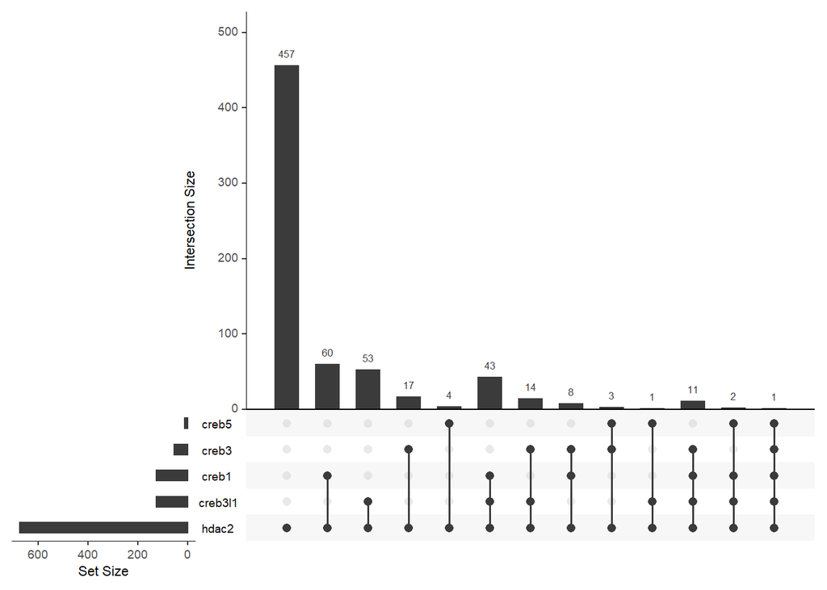

```r
regionUpset(listofRegions_hdac2_22, reference = peaks_hdac2_chr22)
```

Figure 6.17a: A regionOverlaps plot for CREB family members plus HDAC2 for chromosome 22 Figure 6.17b: A regionUpset plot for CREB family members plus HDAC2 for chromosome 22

HDAC2 seems to have most intersections with the CREB family members especially CREB1 followed by CREB3l1.

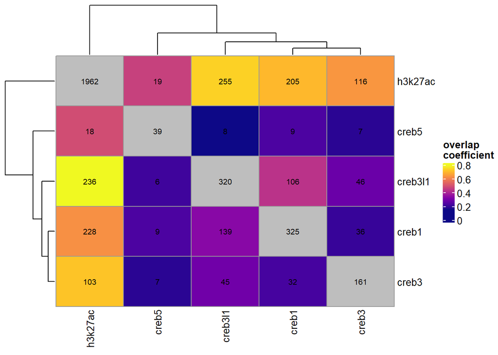

```r
# H3K27ac
listofRegions_h3k27ac_22 <- list(creb1=peaks_creb1_chr22, creb3=peaks_creb3_chr22, creb3l1=peaks_creb3l1_chr22, creb5=peaks_creb5_chr22, h3k27ac=peaks_h3k27ac_chr22)
regionOverlaps(listofRegions_h3k27ac_22)
```

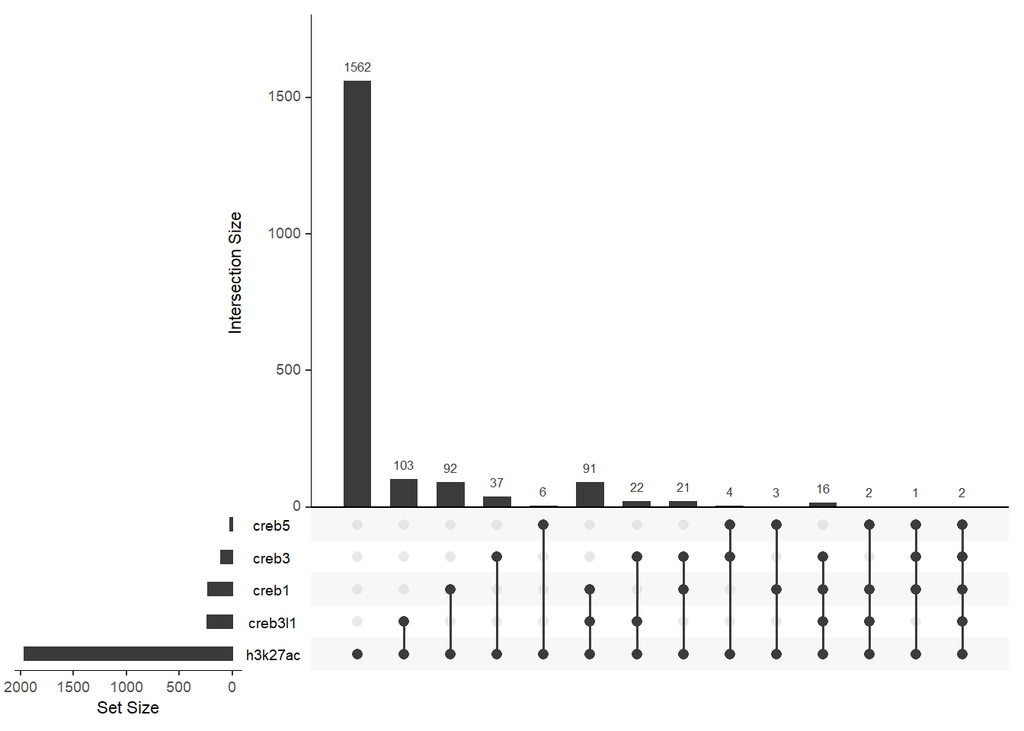

```r
regionUpset(listofRegions_h3k27ac_22, reference = peaks_h3k27ac_chr22)
```

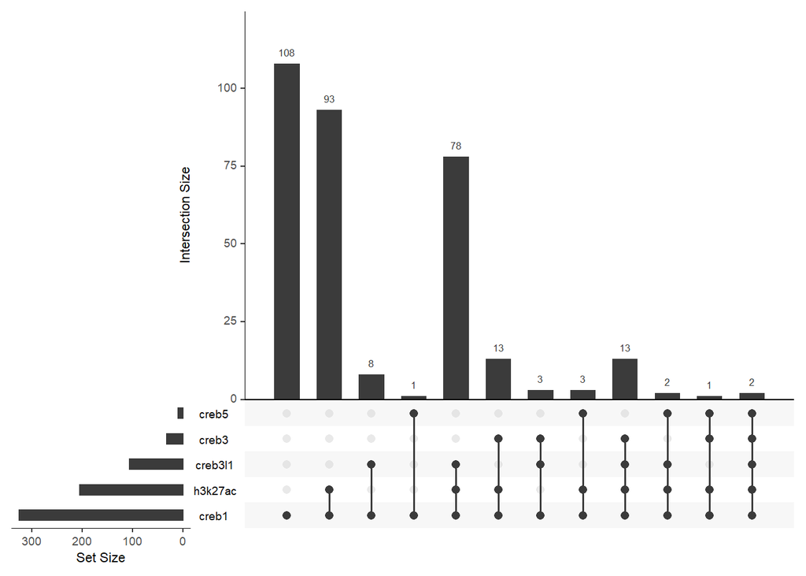

```r
regionUpset(listofRegions_h3k27ac_22, reference = peaks_creb1_chr22)
```

Figure 6.18a: A regionOverlaps plot for CREB family members plus H3K27ac for chromosome 22 Figure 6.18b: A regionUpset plot for CREB family members plus H3K27ac for chromosome 22

H3K27ac seems to intersect most with CREB3l1 and CREB1 then CREB3, and barely with CREB5.

## Doing analysis according to clusters

```r
# create a list with all the peaks on chromosome 22
peak_list_cf_22 <- GRangesList("Peaks CREB1"=peaks_creb1_chr22, "Peaks CREB3"=peaks_creb3_chr22, "Peaks CREB3L1"=peaks_creb3l1_chr22, "Peaks CREB5"=peaks_creb5_chr22, "Peaks CREBBP"=peaks_crebbp_chr22, "Peaks JUN"=peaks_jun_chr22, "Peaks EP300"=peaks_ep300_chr22, "Peaks HDAC2"=peaks_hdac2_chr22, "Peaks H3K27ac"=peaks_h3k27ac_chr22, compress=TRUE)
# merge the peaks together to create one list of non-overlapping regions
merged_peaks_cf_22 <- reduce(unlist(peak_list_cf_22))
# make a list of the signal p-values
pv_list_cf <- list(CREB1="signal_pv_creb/signal_pv_creb1.bw", CREB3="signal_pv_creb/signal_pv_creb3.bw", CREB3L1="signal_pv_creb/signal_pv_creb3l1.bw", CREB5="signal_pv_creb/Signal_pv_creb5.bw", CREBBP="signal_pv_cofactors/signal_pv_crebbp.bw", JUN="signal_pv_cofactors/signal_pv_jun.bw", EP300="signal_pv_cofactors/signal_pv_ep300.bw", HDAC2="signal_pv_cofactors/signal_pv_hdac2.bw", H3K27ac="H3K27ac/h3k27ac_signal_pv.bw")
# we obtain the matrix of the signal around the regions:
m_creb1_cf_22 <- signal2Matrix(pv_list_cf, merged_peaks_cf_22)
```

```
## Reading signal_pv_creb/signal_pv_creb1.bw
```

```
## Reading signal_pv_creb/signal_pv_creb3.bw
```

```
## Reading signal_pv_creb/signal_pv_creb3l1.bw
```

```
## Reading signal_pv_creb/Signal_pv_creb5.bw
```

```
## Reading signal_pv_cofactors/signal_pv_crebbp.bw
```

```
## Reading signal_pv_cofactors/signal_pv_jun.bw
```

```
## Reading signal_pv_cofactors/signal_pv_ep300.bw
```

```
## Reading signal_pv_cofactors/signal_pv_hdac2.bw
```

```
## Reading H3K27ac/h3k27ac_signal_pv.bw
```

```
## `use_raster` is automatically set to TRUE for a matrix with more than
## 2000 rows. You can control `use_raster` argument by explicitly setting
## TRUE/FALSE to it.
##
## Set `ht_opt$message = FALSE` to turn off this message.
```

[output not shown]

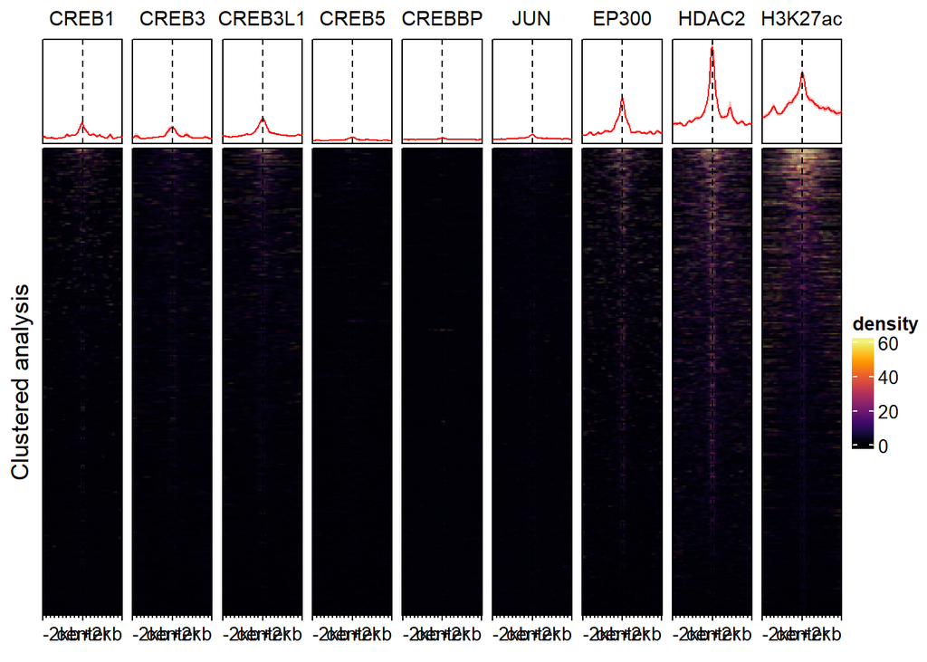

```r
# maybe set an extend and a width?
plotEnrichedHeatmaps(m_creb1_cf_22, row_title="Clustered analysis")
```

Figure 6.19: A heatmap of all the CREB family members plus cofactors and acetylation for chromosome 22.

Following we only proceed with the first approach of plotting groups of experiments and combining them.

## Reusing approach 1 from before

The first approach is to plot two groups of experiments seperately, so that they have their own color scale and then join them afterwarts.

[output not shown]

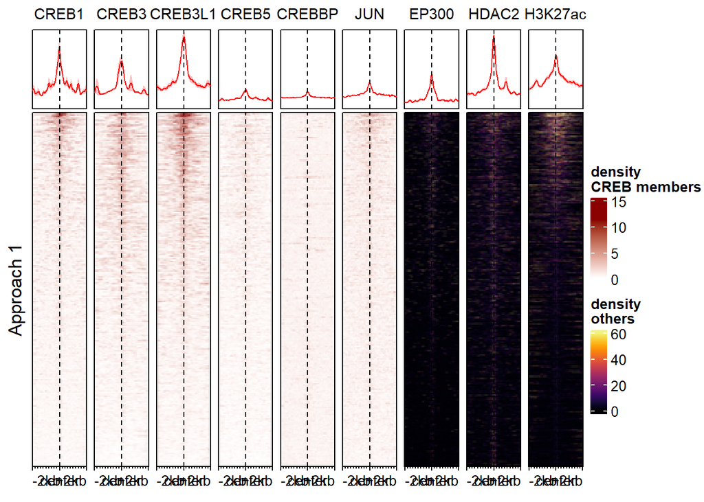

```r
plotEnrichedHeatmaps(m_creb1_cf_22[1:6], scale_title="density\nCREB members", colors=c("white","darkred"), row_title="Approach 1") + plotEnrichedHeatmaps(m_creb1_cf_22[7:9], scale_title="density\nothers", row_title="Approach 1")
```

Figure 6.20: Approach 1 for chromosome 22

### Cluster

```r
cl_2_22 <- clusterSignalMatrices(m_creb1_cf_22, k=7)
```

```
##   ~92% of the variance explained by clusters
```

```r
# 10 clusters explain 95% of the variance
# 7 clusters explain 92% of the variance
# 5 clusters explain 89% of the variance
# so let's go with 7
merged_peaks_cf_22$cluster <- cl_2_22
```

[output not shown]

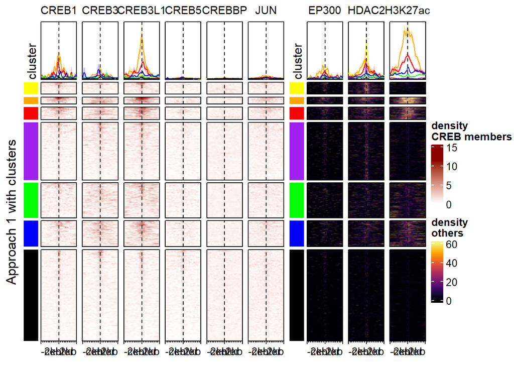

```r
set.seed(124)
mycolors_3 <- c("1"="yellow", "2"="orange", "3"="red", "4"="purple", "5"="green", "6"="blue", "7"="black")
plotEnrichedHeatmaps(m_creb1_cf_22[1:6], row_split = cl_2_22, scale_title="density\nCREB members", colors=c("white","darkred"), mean_color=mycolors_3, row_title="Approach 1 with clusters") + plotEnrichedHeatmaps(m_creb1_cf_22[7:9], row_split = cl_2_22, scale_title="density\nothers", mean_color=mycolors_3, row_title="Approach 1 with clusters")
```

Figure 6.21: A heatmap of the CREB family members and cofactors and acetylation for chromosome 22 split up into 7 clusters.